# PX457 Assignment 6: Machine Learning for image recognition

### Dr Albert Bartók-Pártay, University of Warwick (2026)

#### marks: 15% of PX457 (2.25 CATs)

## Context

This assignment focusses on computer vision, and in particular, image recognition using neural networks. This family of techniques has applications in dozens of fields, but we are going to look at a few basic concepts which illustrate general practices in the field of Machine Learning.

Computer vision can assist with quantification of image analysis: in the current context it can essentially "view" large numbers of images and perform tasks that humans can do, but not necessarily in a consistent, automated manner, such as identifying the defects present in each one.

We will first familiarise ourselves with techinques by applying them to a well-known dataset, the `Hello World` of computer vision: the [MNIST handwritten digit dataset](https://en.wikipedia.org/wiki/MNIST_database). Due to resource limitations (mainly the lack of GPUs on Noteable) we will be using very small and limited models, only applying a fraction of the available data. However, the concepts used here can be easily scaled up in production environments.

## Instructions

Follow the notebook: read the description of the various concepts and run the code cells in sequence. At *Tasks*, you are expected to complete the code or write a short discussion, as [Markdown](https://www.markdownguide.org/) text - you needn't worry about formatting and feel free to write plain text.

Wherever you are expected to write code, you will see `raise NotImplementedError()`. This blocks the cell execution and serves as a reminder to complete a coding task. You should delete this line and replace it with your code.

Please do not duplicate cells, that includes copy-pasting entire cells. You may copy-paste the content of a cell, or make brand new cells. Please do not change the type of the cell. This notebook uses **code** and **markdown** cells - keep these as they are. Please note that autograding will run the entire notebook sequentially, therefore make sure you test your work in a similar fashion.

The entire notebook, when completed according to instructions, should take not more than 10 minutes to run. Please do not exceed this runtime. If your code takes significantly longer to run, it's due to either a mistake or not following the instructions closely.

Before you submit this assignment, make sure everything runs as expected. First, **restart the kernel** (in the menubar, select *Kernel*$\to$*Restart Kernel*) and then run all cells (in the menubar, select *Run*$\to$*Run All Cells*).

Make sure you fill in any place that says `YOUR CODE HERE` or `YOUR ANSWER HERE`, as well as your name below. Use the quotation marks `"` around your name, otherwise your notebook will not validate or run.

Remove all instances of `raise NotImplementedError()` which are placeholders, otherwise your code will not validate or run.

```python
# YOUR CODE HERE
YOUR_NAME = "Jabir Hussain"
```

## Environment Setup

The model we will build is based on PyTorch, and its extension TorchVision, so let us first check that our Python environment includes those.

To visualise our models, we will use the `torchview` package, which should be installed first.

```python
import torch
# if your environment does not have torch or torchvision, you can pip install it with this command (uncomment to use)
#!pip install torchvision==0.18.1
# but please avoid doing so if possible - the "Language and Machine Learning" environment has it preinstalled
import torchvision
print('Torch version: ',torch.__version__)
print('Torchvision version: ',torchvision.__version__)

!pip install --user torchview
"""
import sys, site, importlib.util

print("python:", sys.executable)
print("user site:", site.getusersitepackages())
print("ENABLE_USER_SITE:", site.ENABLE_USER_SITE)


print("find_spec(torchview):", importlib.util.find_spec("torchview"))

user_site = site.getusersitepackages()
if user_site not in sys.path:
    sys.path.insert(0, user_site)

print("find_spec(torchview) after path fix:", importlib.util.find_spec("torchview"))

# Now try importing
import torchview
from torchview import draw_graph
print("torchview imported from:", torchview.__file__)
"""
```

```
Torch version:  2.5.1
Torchvision version:  0.20.1
```

[output not shown]

```python
# a few imports

import matplotlib.pyplot as plt
import numpy as np

import torch
import torch.nn as nn
import torch.nn.functional as F
import torch.optim as optim
from torchvision import datasets, transforms
from torch.utils.data import Subset
from torch.optim.lr_scheduler import StepLR

from torchview import draw_graph
from tabulate import tabulate # to print simple tables
from tqdm import tqdm
```

The MNIST dataset is composed of greyscale image files of the digits together with their target labels. To make the image files useful for ML, a transform is defined below. This converts the image pixels into $28\times 28$ `torch` tensors.

```python
transform=transforms.Compose([
        transforms.ToTensor(),
        ])
```

```python
all_train = datasets.QMNIST('./data', what="train", download=True,
                       transform=transform)
all_test = datasets.QMNIST('./data', what="test10k", download=True,
                       transform=transform)
```

#### Inspect the type of data.

```python
print(f"Number of training data points: {len(all_train)}")
print(f"Number of test data points: {len(all_train)}")

image, label = all_train[0] # Each data point is a tuple: image and corresponding label
print(f"Shape of tensor representing an image: {image.shape}") # Note the shape of the tensor: 1 channel (intensity only), 28 x 28 pixels
print(f"Label: {label}") # The label is an integer between 0 and 9
```

```
Number of training data points: 60000
Number of test data points: 60000
Shape of tensor representing an image: torch.Size([1, 28, 28])
Label: 5
```

#### Inspect the first 16 digits. Do the labels look accurate?

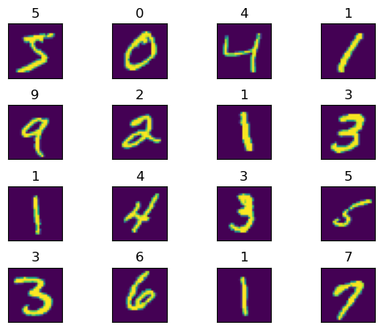

```python
fig, axes = plt.subplots(4,4,gridspec_kw={"hspace":0.5})
for ax,(image,label) in zip(axes.flatten(),all_train):
    ax.imshow(image[0]) # We only care about the one and only channel. Each image is 28 x 28 pixels.
    ax.set_xticks([])
    ax.set_yticks([])
    ax.set_title(label)
plt.show()
```

```python
n_train = 2048
train_indices = np.random.choice(len(all_train),n_train,replace=False)
train_set = Subset(all_train,train_indices)

test_set = all_test
```

```python
train_loader = torch.utils.data.DataLoader(train_set,batch_size = 64)
test_loader = torch.utils.data.DataLoader(test_set,batch_size = 1000)
```

#### The first neural network model

We first build a dense neural network, with a single hidden layer.

This model

1. flattens the $28\times 28$ pixel values into a 1D array, $\mathbf{x}_0$, of $28\times 28 = 784$ numbers;
2. $\mathbf{x}_0$ is transformed into a new vector $\mathbf{x}_1$ of a length of 15, using a parameter matrix $\mathbf{W}_1$ and bias vector $\mathbf{b}_1$: $\mathbf{x}_1 = \mathbf{W}_1 \mathbf{x}_0 + \mathbf{b}_1$
3. the elements of $\mathbf{x}_1$ are passed through the rectified linear unit (ReLU) function, obtaining $\mathbf{x}_1'$: $\mathbf{x}_1' = \mathrm{ReLU}(\mathbf{x}_1)$
4. $\mathbf{x}_1'$ is transformed into a new vector $\mathbf{x}_2$ of a length of 10, using a parameter matrix $\mathbf{W}_2$ and bias vector $\mathbf{b}_2$: $\mathbf{x}_2 = \mathbf{W}_2 \mathbf{x}_1' + \mathbf{b}_2$
5. the elements of $\mathbf{x}_2$ are passed through the $\log \mathrm{softmax}$ function, obtaining $\tilde{\mathbf{y}}$

$\tilde{\mathbf{y}}$ is the output of the model. We are fitting to 10 categories, therefore we define $\tilde{\mathbf{y}}$ as a 10-element vector. The $i$-th element of $\tilde{\mathbf{y}}$ corresponds to the log probability of digit $i$, given the input vector $\mathbf{x}_0$.

Below is a visual representation of the neural network. Not all the 784 input features are represented.

[figure not shown]

```python
class DenseNetwork(nn.Module):
    def __init__(self):
        super(DenseNetwork, self).__init__()
        self.fc1 = nn.Linear(784,15) # The first weight matrix and bias vector
        self.fc2 = nn.Linear(15,10) # The second weight matrix and bias vector

    def forward(self, x):
        x = torch.flatten(x, 1) # step 1
        x = self.fc1(x) # step 2
        x = F.relu(x) # step 3
        x = self.fc2(x) # step 4
        output = F.log_softmax(x, dim=1) # step 5
        return output
```

#### Activation functions

The rectified linear unit (ReLU) function is very popular and it is defined as $$\textrm{ReLU}(x)=\begin{cases} x & \textrm{if}\quad x>0\\ 0 & \textrm{otherwise} \end{cases}$$

The $\log \textrm{softmax}$ function operates on a vector input $\mathbf{x}$, resulting in $\mathbf{y}$, where $$y_i = \log \left( \frac{\exp(x_i)}{\sum_j \exp(x_j)} \right) $$

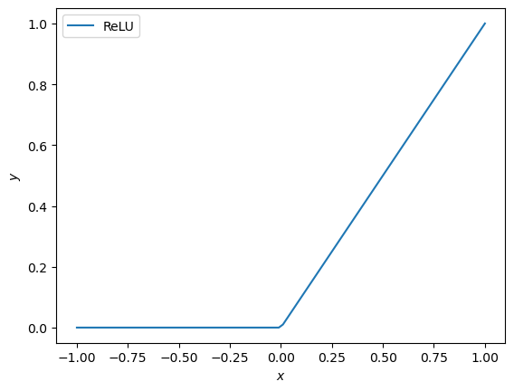

```python
# Visualising the ReLU function

x = torch.linspace(-1,1,100)
relu_x = F.relu(x)
plt.plot(x,relu_x,label="ReLU")
plt.xlabel(r"$x$")
plt.ylabel(r"$y$")
plt.legend()
plt.show()
```

```python
model = DenseNetwork() # Based on the model definition, we generate an instance of the model, with random weights.
```

#### Visualise the model

You will not be the first person finding the model definition somewhat confusing. We can use the `draw_graph()` method to visualise the computational graph - note that it needs to build it first, hence the requirement of `input_data`.

Parameters are stored as tensors. Those which are free to be optimised have the attribute `requires_grad` set to `True`.

```python
for param in model.parameters():
    print(type(param), param.requires_grad, param.size())
```

```
<class 'torch.nn.parameter.Parameter'> True torch.Size([15, 784])
<class 'torch.nn.parameter.Parameter'> True torch.Size([15])
<class 'torch.nn.parameter.Parameter'> True torch.Size([10, 15])
<class 'torch.nn.parameter.Parameter'> True torch.Size([10])
```

```python
image, label = all_train[0] # Each data point is a tuple: image and corresponding label

image = image[None,:,:,:] # We add an extra axis to the front

model_graph = draw_graph(model,input_data=image)
model_graph.visual_graph
```

[figure not shown]

```python
# This is also informative:
print(model)
```

```
DenseNetwork(
  (fc1): Linear(in_features=784, out_features=15, bias=True)
  (fc2): Linear(in_features=15, out_features=10, bias=True)
)
```

#### Task

Determine the number of adjustable (trainable) parameters in the `DenseNetwork` model.

[1 mark]

```python
n_trainable_parameters = 0

for p in model.parameters():
    if p.requires_grad:
        n_trainable_parameters += p.numel()
```

#### Initial model performance

Since the model was initiated with random parameters, we don't expect to do very well. Let's try with the first data point.

```python
image, label = all_train[0] # Each data point is a tuple: image and corresponding label
image = image[None,:,:,:]

print(model(image))
```

```
tensor([[-2.1987, -2.3559, -2.2500, -2.4611, -2.2359, -2.5727, -2.1761, -2.2958,
         -2.4907, -2.0934]], grad_fn=<LogSoftmaxBackward0>)
```

#### Initial model performance

You'll likely observe that each 10 categories have roughly equal predicted log probabilities, in accordance with a randomly initialised model.

#### Fitting the model

To fit the model we need to define a loss. We will use the **negative log likelihood** loss function, a common choice in classification tasks. $$\mathcal{L} = -\sum_{i\in \mathrm{batch}} \tilde{y}_{t_i}(\mathbf{x}_i)$$

where $t_i$ is the target label of the $i$-th data point in the batch, $\tilde{y}_{t_i}$ is the $t_i$-th element of the predicted $\tilde{\mathbf{y}}$ vector at data point $\mathbf{x}_i$. Remember that $\tilde{\mathbf{y}}(\mathbf{x}_i)$ is the output of the $\log \textrm{softmax}$ function. The optimiser will *minimise* this loss function, therefore *maximising* the predicted log likelihood of the correct label prediction.

In prediction mode, we simply choose the index of the largest predicted log likelihood - this is the category assigned by the model to the datapoint.

```python
def train(model, train_loader, optimizer, epoch, device = "cpu"):

    for batch_idx, (data, target) in enumerate(train_loader): # go through all batches within the training data set
        data, target = data.to(device), target.to(device) # extract image data and target
        optimizer.zero_grad() # reset gradients
        output = model(data) # determine the outputs of all data points within the batch with the current model
        loss = F.nll_loss(output, target) # calculate the loss corresponding to the data points within the batch
        loss.backward() # calculate the gradients using backpropagation, w.r.t. all parameters in the model
        optimizer.step() # advance the parameters using the gradients.
        if batch_idx % 16 == 0: # print progress
            print('Train Epoch: {} [{}/{} ({:.0f}%)]\tLoss: {:.6f}'.format(
                epoch, batch_idx * len(data), len(train_loader.dataset),
                100. * batch_idx / len(train_loader), loss.item()))

def test(model, test_loader, device = "cpu"):
    test_loss = 0
    correct = 0
    with torch.no_grad(): # no need for gradients
        for data, target in test_loader: # go through all batches within the testing data set
            data, target = data.to(device), target.to(device) # extract image data and target
            output = model(data) # determine the outputs of all data points within the batch with the current model
            test_loss += F.nll_loss(output, target, reduction='sum').item()  # sum up batch loss
            pred = output.argmax(dim=1, keepdim=True)  # get the index of the max log-probability
            correct += pred.eq(target.view_as(pred)).sum().item() # calculate how many predictions are correct

    test_loss /= len(test_loader.dataset) # average the loss

    print('\nTest set: Average loss: {:.4f}, Accuracy: {}/{} ({:.0f}%)\n'.format(
        test_loss, correct, len(test_loader.dataset),
        100. * correct / len(test_loader.dataset)))

    return test_loss, correct / len(test_loader.dataset)
```

```python
# We apply a simple optimiser
optimizer = optim.Adadelta(model.parameters(), lr=1)
```

```python
# Training the network
num_epochs = 16
for epoch in range(1, 1+num_epochs):
        train(model, train_loader, optimizer, epoch)
        test(model, test_loader)
```

```
Train Epoch: 1 [0/2048 (0%)]	Loss: 2.311768
Train Epoch: 1 [1024/2048 (50%)]	Loss: 1.422640

Test set: Average loss: 0.9304, Accuracy: 7478/10000 (75%)

Train Epoch: 2 [0/2048 (0%)]	Loss: 0.876034
Train Epoch: 2 [1024/2048 (50%)]	Loss: 0.626152

Test set: Average loss: 0.5977, Accuracy: 8308/10000 (83%)

Train Epoch: 3 [0/2048 (0%)]	Loss: 0.519589
Train Epoch: 3 [1024/2048 (50%)]	Loss: 0.438095

Test set: Average loss: 0.4829, Accuracy: 8614/10000 (86%)

Train Epoch: 4 [0/2048 (0%)]	Loss: 0.383844
Train Epoch: 4 [1024/2048 (50%)]	Loss: 0.359181

Test set: Average loss: 0.4304, Accuracy: 8750/10000 (88%)

Train Epoch: 5 [0/2048 (0%)]	Loss: 0.311709
Train Epoch: 5 [1024/2048 (50%)]	Loss: 0.315861

Test set: Average loss: 0.4002, Accuracy: 8834/10000 (88%)

Train Epoch: 6 [0/2048 (0%)]	Loss: 0.265327
Train Epoch: 6 [1024/2048 (50%)]	Loss: 0.285122

Test set: Average loss: 0.3824, Accuracy: 8886/10000 (89%)

Train Epoch: 7 [0/2048 (0%)]	Loss: 0.233700
Train Epoch: 7 [1024/2048 (50%)]	Loss: 0.259698

Test set: Average loss: 0.3700, Accuracy: 8904/10000 (89%)

Train Epoch: 8 [0/2048 (0%)]	Loss: 0.210096
Train Epoch: 8 [1024/2048 (50%)]	Loss: 0.238848

Test set: Average loss: 0.3628, Accuracy: 8921/10000 (89%)

```

[output cut: 24 more lines]

```

Train Epoch: 14 [0/2048 (0%)]	Loss: 0.137154
Train Epoch: 14 [1024/2048 (50%)]	Loss: 0.150305

Test set: Average loss: 0.3503, Accuracy: 8985/10000 (90%)

Train Epoch: 15 [0/2048 (0%)]	Loss: 0.129352
Train Epoch: 15 [1024/2048 (50%)]	Loss: 0.140304

Test set: Average loss: 0.3505, Accuracy: 8988/10000 (90%)

Train Epoch: 16 [0/2048 (0%)]	Loss: 0.122388
Train Epoch: 16 [1024/2048 (50%)]	Loss: 0.130474

Test set: Average loss: 0.3513, Accuracy: 8988/10000 (90%)
```

#### Evaluation of the model and further insights

In the following, we evaluate the model on all test images. We then determine the [confusion matrix](https://en.wikipedia.org/wiki/Confusion_matrix#Confusion_matrices_with_more_than_two_categories): for every digit between 0-9, we count how many were predicted in each category. A perfect model would result in an exactly diagonal matrix. Below we print the table and also visualise it as a heatmap.

```python
all_test_predict = np.array([])
all_test_actual = np.array([])
for data, target in test_loader: # go through all batches within the testing data set
    data, target = data.to("cpu"), target.to("cpu") # extract image data and target
    output = model(data) # determine the outputs of all data points within the batch with the current model

    ind = output.argmax(dim=1, keepdim=False)


    all_test_predict = np.concatenate((all_test_predict,ind))
    all_test_actual = np.concatenate((all_test_actual,target))
```

```python
confusion_matrix = np.array([[np.count_nonzero(all_test_predict[all_test_actual==i]==j) for j in range(10)] for i in range(10) ])
```

```
┌────┬─────┬──────┬─────┬─────┬─────┬─────┬─────┬─────┬─────┬─────┐
│    │   0 │    1 │   2 │   3 │   4 │   5 │   6 │   7 │   8 │   9 │
├────┼─────┼──────┼─────┼─────┼─────┼─────┼─────┼─────┼─────┼─────┤
│  0 │ 950 │    0 │   4 │   2 │   0 │   6 │  14 │   1 │   3 │   0 │
│  1 │   0 │ 1106 │   1 │  10 │   0 │   2 │   4 │   2 │  10 │   0 │
│  2 │  16 │    7 │ 881 │  47 │   9 │   1 │  19 │  19 │  31 │   2 │
│  3 │   3 │    1 │  12 │ 939 │   1 │  17 │   3 │  16 │  11 │   7 │
│  4 │   3 │    2 │   5 │   2 │ 895 │   3 │  11 │   3 │  13 │  45 │
│  5 │  18 │    4 │   6 │  71 │  15 │ 706 │  24 │  11 │  25 │  12 │
│  6 │  16 │    3 │   8 │   0 │  28 │   8 │ 887 │   2 │   6 │   0 │
│  7 │   5 │   16 │  24 │  10 │   6 │   0 │   0 │ 926 │   4 │  37 │
│  8 │  15 │    4 │   5 │  49 │  14 │  32 │  12 │  11 │ 817 │  15 │
│  9 │  16 │    7 │   3 │  17 │  46 │   5 │   0 │  26 │   8 │ 881 │
└────┴─────┴──────┴─────┴─────┴─────┴─────┴─────┴─────┴─────┴─────┘
```

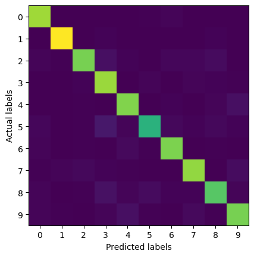

```python
print(tabulate(confusion_matrix, showindex=True, headers=range(10), tablefmt="simple_outline"))
fig, ax = plt.subplots(1,1)
ax.imshow(confusion_matrix)
ax.set_xticks(range(10))
ax.set_yticks(range(10))
ax.set_xlabel("Predicted labels")
ax.set_ylabel("Actual labels")
plt.show()
```

### Choosing between procedures and models: **validation**

So far, we have used two data sets: training and testing.

- The **training** set was used to calculate the gradients w.r.t. the model parameters and to optimise the model.
- The **test**, independent of the training set, was used to evaluate the performance of the model on **unseen** data. The main purpose of the **test** set is to assess the real-world performance of the model, therefore it should not be contaminated with the **training** set.

It is common to use a third data set, called the **validation** set. There are no set rules, but typically the validation set is a subset of the training set, and it is usually smaller than the training or the test set. The purpose of the validation set is to avoid overfitting: that is, to monitor the performance of the models during optimisation, or to compare models obtained with different hyperparameters (e.g. learning rates, network architecture, etc.)

Here we will use the validation set to calculate the **validation loss** as well as the percentage of correct assignments on the validation set.

```python
# Update the train() function to calculate the validation loss in every epoch.

def train(model, train_loader, validation_loader, optimizer, epoch, device = "cpu"):

    for batch_idx, (data, target) in enumerate(train_loader): # go through all batches within the training data set
        data, target = data.to(device), target.to(device) # extract image data and target
        optimizer.zero_grad() # reset gradients
        output = model(data) # determine the outputs of all data points within the batch with the current model
        loss = F.nll_loss(output, target) # calculate the loss corresponding to the data points within the batch
        loss.backward() # calculate the gradients using backpropagation, w.r.t. all parameters in the model
        optimizer.step() # advance the parameters using the gradients.

    validation_loss = 0
    validation_correct = 0
    with torch.no_grad(): # no need for gradients
        for data, target in validation_loader:
            data, target = data.to(device), target.to(device) # extract image data and target
            output = model(data) # determine the outputs of all data points within the batch with the current model
            validation_loss += F.nll_loss(output, target, reduction='sum').item()  # sum up batch loss
            pred = output.argmax(dim=1, keepdim=True)  # get the index of the max log-probability
            validation_correct += pred.eq(target.view_as(pred)).sum().item() # calculate how many predictions are correct
    return validation_loss, validation_correct / len(validation_loader.dataset)
```

We take the last 1024 of the original training data points and reserve them as a validation set.

```python
n_validation = 1024
validation_indices = range(len(all_train)-n_validation,len(all_train)) # Last n_validation points
validation_set = Subset(all_train,validation_indices)

validation_loader = torch.utils.data.DataLoader(validation_set,batch_size=64)
```

In the following, we will always choose the training set such that the validation points are excluded.

```python
n_train = 1024

train_indices = np.random.choice(len(all_train)-n_validation,n_train,replace=False) # Random indices from all training data points except the last n_validation
train_set = Subset(all_train,train_indices)
train_loader = torch.utils.data.DataLoader(train_set,batch_size = 64)
```

#### Monitoring the progress of training

Run the following code to capture the validation loss and the fraction of correct assignments for every epoch, using the updated `train()` function.

```python
num_epochs = 128

model = DenseNetwork() # Based on the model definition, we generate an instance of the model, with random weights.
optimizer = optim.Adadelta(model.parameters(), lr=1)

loss = []
correct = []
for epoch in tqdm(range(1, 1+num_epochs)):
    validation_loss, validation_correct = train(model, train_loader, validation_loader, optimizer, epoch)
    loss.append(validation_loss)
    correct.append(validation_correct)

loss = np.array(loss)
correct = np.array(correct)
```

We plot the validation loss and the fraction of correct assignments as a function of epochs.

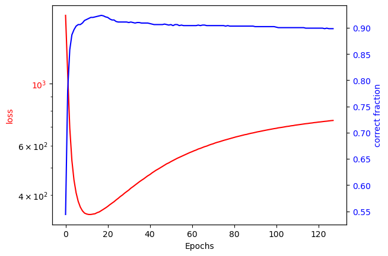

```python
fig, ax1 = plt.subplots()

ax1.semilogy(loss,"r")
ax2 = ax1.twinx()
ax2.plot(correct,"b")

ax1.set_xlabel("Epochs")
ax1.set_ylabel("loss",color="r")
ax1.tick_params(axis='y', labelcolor="r")

ax2.set_ylabel("correct fraction",color="b")
ax2.tick_params(axis='y', labelcolor="b")
#plt.plot(loss)
#plt.plot(correct)
plt.show()
```

#### Task

Discuss the obtained figure. Explain how our optimisation procedure gives rise to the observed behaviour.

[1 mark]

For the early epochs, the negative log-likelihood is high with low accuracy. This is because the network starts with almost uniform class probabilities. As the number of epochs goes, the model has learned as much as it can within the confinements of the dataset, so the correct fraction plateaus. On the other hand, the loss increases with the number of epochs since the optimiser continues to update the model weights. The negative log-likelihood depends on the probability of the true label. The set of misclassified validation points becomes fixed, thus the confidence in their incorrectness makes the log-probability for true values smaller and thus negative log-likelihood increases.

#### Hold out method

A common practice is to take the best performing model during the optimisation, and use that as the definitive model. You can take a "snapshot" of a model by using the `deepcopy()` function or save the model to the disk.

```python
from copy import deepcopy
```

```python
save_model = deepcopy(model) # save_model is now an exact and independent replica of model
```

#### Task

In the following cell, implement the **hold out** method, using the validation loss. At the end of the training:

- `best_loss` should contain the lowest value of the validation loss
- `best_correct` the corresponding value of the fraction of correctly assigned validation data points
- `best_epoch` the corresponding index of epoch
- `best_model` the corresponding best performing model.

[1.5 mark]

```python
model = DenseNetwork() # Based on the model definition, we generate an instance of the model, with random weights.
optimizer = optim.Adadelta(model.parameters(), lr=1)

num_epochs = 128

loss = []
correct = []

best_loss = float("inf")
best_correct = 0
best_epoch = 0
best_model = deepcopy(model)

for epoch in tqdm(range(1, 1+num_epochs)):
    val_loss, val_corr = train(model, train_loader, validation_loader, optimizer, epoch)
    loss.append(val_loss)
    correct.append(val_corr)
    if val_loss < best_loss:
        best_loss = val_loss       # Update new best loss record
        best_correct = val_corr # Update corresponding accuracy
        best_epoch = epoch                # Record epoch this happened in
        best_model = deepcopy(model)

loss = np.array(loss)
correct = np.array(correct)

print(best_loss)
print(best_correct)
```

```
327.7697768211365
0.916015625
```

#### Task

Now plot the progress of the optimisation, indicating with markers where the best performing model was obtained.

[0.5 mark]

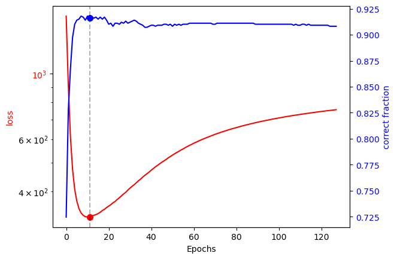

```
Test set: Average loss: 0.3903, Accuracy: 8853/10000 (89%)

(0.39033375854492186, 0.8853)
```

```python
fig, ax1 = plt.subplots()

ax1.semilogy(loss,"r")

ax2 = ax1.twinx()
ax2.plot(correct,"b")

best = int(np.argmin(loss))
ax1.semilogy(best, loss[best], "ro", markersize=7)
ax2.plot(best, correct[best], "bo", markersize=7)
ax1.axvline(best, color="k", linestyle="--", alpha=0.3)

ax1.set_xlabel("Epochs")
ax1.set_ylabel("loss",color="r")
ax1.tick_params(axis='y', labelcolor="r")

ax2.set_ylabel("correct fraction",color="b")
ax2.tick_params(axis='y', labelcolor="b")
#plt.plot(loss)
#plt.plot(correct)
plt.show()

# Model perfomance on best model
print(test(best_model, test_loader))
```

#### Scheduling

The observed minimum in the validation loss indicates that after the model performance saturates, subsequent training steps are not particularly useful.

Schedulers try to solve this problem. One of the inputs to the optimiser was the learning rate (`lr`) parameter, which we set to 1. Schedulers adapt this value according to a recipe, usually decreasing it as the optimisation proceeds. We will use a simple scheduler in the following: every $s$ step the learning rate $\eta$ is updated as $\eta' = \eta \gamma$.

```python
from torch.optim.lr_scheduler import StepLR
```

```python
model = DenseNetwork() # Based on the model definition, we generate an instance of the model, with random weights.
optimizer = optim.Adadelta(model.parameters(), lr=1)

scheduler = StepLR(optimizer, step_size=4, gamma=0.75)

num_epochs = 128

loss = []
correct = []

best_loss = float("inf")
best_correct = 0
best_epoch = 0
best_model = deepcopy(model)

for epoch in tqdm(range(1, 1+num_epochs)):
    val_loss, val_corr = train(model, train_loader, validation_loader, optimizer, epoch)
    scheduler.step()

    loss.append(val_loss)
    correct.append(val_corr)
    if val_loss < best_loss:
        best_loss = val_loss       # Update new best loss record
        best_correct = val_corr # Update corresponding accuracy
        best_epoch = epoch                # Record epoch this happened in
        best_model = deepcopy(model)

loss = np.array(loss)
correct = np.array(correct)
```

#### Task

Determine the final learning rate in the cell below.

[0.5 mark]

```python
final_learning_rate = optimizer.param_groups[0]["lr"]
print(final_learning_rate)
```

```
0.00010045242572063329
```

#### Task

Plot the loss and the fraction of correct assignments as a function of epochs, obtained from the training with the scheduler.

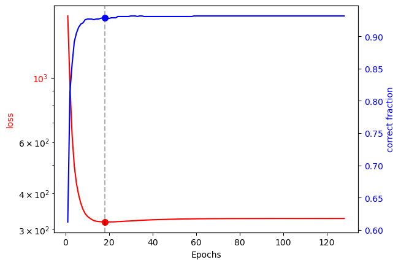

```python
epochs = np.arange(1, len(loss) + 1)

fig, ax1 = plt.subplots()

# loss (left axis, log scale)
ax1.semilogy(epochs, loss, "r")
ax1.set_xlabel("Epochs")
ax1.set_ylabel("loss", color="r")
ax1.tick_params(axis="y", labelcolor="r")

ax2 = ax1.twinx()
ax2.plot(epochs, correct, "b")
ax2.set_ylabel("correct fraction", color="b")
ax2.tick_params(axis="y", labelcolor="b")

best_idx = best_epoch - 1
ax1.semilogy(best_epoch, loss[best_idx], "ro", markersize=7)
ax2.plot(best_epoch, correct[best_idx], "bo", markersize=7)
ax1.axvline(best_epoch, color="k", linestyle="--", alpha=0.3)

plt.show()
```

#### Task

Discuss how the scheduler helped the training process and what the advantages are of using one.

[1 mark]

The use of a scheduler allows training to take large steps early in the training process, significantly improving accuracy and minimising loss, then taking smaler steps as performance plateaus. This gives a fast and stable method to improve convergence whilst mitigating overfitting.

#### Training set size and learning curve

So far, another arbitrary setting was the number of training data points we used. Is 1024 too many? Not enough? Using too little leads to a suboptimal model. Using too much requires unnecessary amounts of resources.

It is common practice to train a set of models using increasing number of data points. By looking at some performance metric, such as loss on the validation or test set we can determine an optimal size for the data set, given a model complexity.

### Task

Using the training set sizes below, choose appropriately sized data sets, and run a series of trainings. Store the best models and various metrics in the pre-initialised dictionaries.

[1 mark]

```python
n_trains = [128, 256, 512, 1024, 2048, 4096]
best_models = {n_train:None for n_train in n_trains}
best_losses = {n_train:float("inf") for n_train in n_trains}
best_corrects = {n_train:0 for n_train in n_trains}
best_epochs = {n_train:0 for n_train in n_trains}

num_epochs = 128

for n_train in n_trains:

    train_set = Subset(all_train, range(n_train))
    train_load = torch.utils.data.DataLoader(train_set, batch_size=64, shuffle=True)

    model = DenseNetwork()
    optimizer = optim.Adadelta(model.parameters(), lr=1)

    best_loss = float("inf")
    best_correct = 0
    best_epoch = 0
    best_model = deepcopy(model)

    for epoch in tqdm(range(1, num_epochs + 1), desc=f"n_train={n_train}", leave=False):
        val_loss, val_corr = train(model, train_load, validation_loader, optimizer, epoch)
        if val_loss < best_loss:
            best_loss, best_correct, best_epoch = val_loss, val_corr, epoch
            best_model = deepcopy(model)

    best_models[n_train] = best_model
    best_losses[n_train] = best_loss
    best_corrects[n_train] = best_correct
    best_epochs[n_train] = best_epoch
```

#### Task

For each best model for a given data set size, calculate test metrics below.

[0.5 mark]

```python
test_losses = []
test_corrects = []

for n_train in n_trains:
    model = best_models[n_train]

    model_device = next(model.parameters()).device

    test_loss, test_corr = test(model, test_loader, device=model_device)
    test_losses.append(test_loss)
    test_corrects.append(test_corr)

test_losses = np.array(test_losses)
test_corrects = np.array(test_corrects)
```

```
Test set: Average loss: 1.0282, Accuracy: 6819/10000 (68%)


Test set: Average loss: 0.7319, Accuracy: 7708/10000 (77%)


Test set: Average loss: 0.5521, Accuracy: 8322/10000 (83%)


Test set: Average loss: 0.4267, Accuracy: 8710/10000 (87%)


Test set: Average loss: 0.3936, Accuracy: 8869/10000 (89%)


Test set: Average loss: 0.3246, Accuracy: 9055/10000 (91%)
```

#### Task

Plot the performance metric(s) on the **test** set. Set logarithmic scale on the horizontal axis.

[0.5 mark]

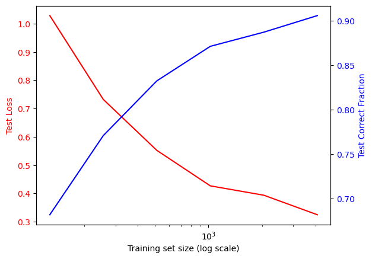

```python
fig, ax = plt.subplots()

ax.plot(n_trains, test_losses, "r")
ax.set_xscale("log")
ax.set_xlabel("Training set size (log scale)")
ax.set_ylabel("Test Loss", color="r")
ax.tick_params(axis="y", labelcolor="r")

ax2 = ax.twinx()
ax2.plot(n_trains, test_corrects, "b")
ax2.set_ylabel("Test Correct Fraction", color="b")
ax2.tick_params(axis="y", labelcolor="b")

plt.show()
```

#### Task

Discuss below how the models change with more data used in the training set and what the implications are for the training.

[1 mark]

The loss falls and accuracy rises over the test set as the training set size increases. The model generalises better, and training over more data gives improvement in accuracy at the cost of compute.

### Convolutional Neural Networks (CNNs)

So far, we used a simple, fully connected neural network as our model. We could make it more complex by adding more hidden layers or increasing the number of nodes in the hidden layer(s). Both of these actions would significantly increase the number of parameters, and could potentially require ever larger training sets.

Instead of increasing the number of parameters and the complexity of the model, CNNs aim to extract features which are more geometrically informed than the nodes of hidden layers.

An important ingredient is the convolution operation.

#### Exercise

In the following code cell you can convince yourself about the operation of the 2D convolution operation. Based on the manually set weights, bias and input, you should be able to work out what the output should be.

Of course, in a practical model weights and biases are set to random initial values and optimisied using data.

```python
c1 = nn.Conv2d(1, 1, 3, 1) # input channels, output channels, size of kernel, stride

c1.bias = nn.Parameter(data=torch.tensor([0.5],dtype=torch.float))
weight = torch.tensor(
    [
        [1.0, 0.0, 1.0],
        [0.0, 2.0, 0.0],
        [1.0, 0.0, 1.0],
    ],dtype=torch.float
)
c1.weight = nn.Parameter(data=weight[None,None,:,:])

print(f"weights:\n {weight}")
print(f"bias:\n {c1.bias}")
x = torch.arange(16,dtype=torch.float).reshape((4,4))
x = x[None,None,:,:]
print(f"input:\n{x}")
print(f"output:\n {c1(x)}")
```

```
weights:
 tensor([[1., 0., 1.],
        [0., 2., 0.],
        [1., 0., 1.]])
bias:
 Parameter containing:
tensor([0.5000], requires_grad=True)
input:
tensor([[[[ 0.,  1.,  2.,  3.],
          [ 4.,  5.,  6.,  7.],
          [ 8.,  9., 10., 11.],
          [12., 13., 14., 15.]]]])
output:
 tensor([[[[30.5000, 36.5000],
          [54.5000, 60.5000]]]], grad_fn=<ConvolutionBackward0>)
```

#### Exercise

Another operation is max pooling. In the following cell it's demonstrated how max pooling operates on the same input as above.

```python
print(f"input:\n{x}")
print(f"output:\n {F.max_pool2d(x, 2)}")
```

```
input:
tensor([[[[ 0.,  1.,  2.,  3.],
          [ 4.,  5.,  6.,  7.],
          [ 8.,  9., 10., 11.],
          [12., 13., 14., 15.]]]])
output:
 tensor([[[[ 5.,  7.],
          [13., 15.]]]])
```

#### A CNN model

Now we're ready to define a CNN model. This one will take a greyscale image (1 channel only!) and

- apply the first convolution layer, this creates 4 new channels
- pass the results through a ReLU
- apply the second convolution layer, this keeps the 4 channels, but also mixes the previous four
- pass the results through a ReLU
- apply a max pool
- after flattening the result, apply a similar deep neural network as we did before.

```python
class CNN(nn.Module):
    def __init__(self):
        super(CNN, self).__init__()
        self.conv1 = nn.Conv2d(1, 4, 3, 1) # input channels, output channels, size of kernel, stride
        self.conv2 = nn.Conv2d(4, 4, 3, 1)
        self.fc1 = nn.Linear(576, 16)
        self.fc2 = nn.Linear(16, 10)

    def forward(self, x):
        x = self.conv1(x)
        x = F.relu(x)
        x = self.conv2(x)
        x = F.relu(x)
        x = F.max_pool2d(x, 2)
        x = torch.flatten(x,1)
        x = self.fc1(x)
        x = F.relu(x)
        x = self.fc2(x)
        output = F.log_softmax(x, dim=1)
        return output
```

Visualise the model

```python
image, label = all_train[0] # Each data point is a tuple: image and corresponding label

image = image[None,:,:,:]
model = CNN()

model_graph = draw_graph(model,input_data=image)
model_graph.visual_graph
```

[figure not shown]

#### Task

Determine the number of adjustable (trainable) parameters in the `CNN` model.

[1 mark]

```python
n_trainable_parameters = sum(
    param.numel() for param in model.parameters() if param.requires_grad
)
print(n_trainable_parameters)
```

```
9590
```

#### Task

The final task is to obtain learning curves for the CNN model, comparable to those you obtained earlier for the conventional NN. Generate models with increasing data set sizes, templated below.

[1 mark]

```python
n_trains = [128, 256, 512, 1024, 2048, 4096]
best_cnn_models = {n_train:None for n_train in n_trains}
best_cnn_losses = {n_train:float("inf") for n_train in n_trains}
best_cnn_corrects = {n_train:0 for n_train in n_trains}
best_cnn_epochs = {n_train:0 for n_train in n_trains}

num_epochs = 64

for n_train in n_trains:

    train_set = Subset(all_train, range(n_train))
    train_load = torch.utils.data.DataLoader(train_set, batch_size=64, shuffle=True)

    model = CNN()
    optimizer = optim.Adadelta(model.parameters(), lr=1)

    best_loss = float("inf")
    best_correct = 0
    best_epoch = 0
    best_model = deepcopy(model)

    for epoch in tqdm(range(1, num_epochs + 1), desc=f"n_train={n_train}", leave=False):
        val_loss, val_corr = train(model, train_load, validation_loader, optimizer, epoch)
        if val_loss < best_loss:
            best_loss, best_correct, best_epoch = val_loss, val_corr, epoch
            best_model = deepcopy(model)

    best_cnn_models[n_train] = best_model
    best_cnn_losses[n_train] = best_loss
    best_cnn_corrects[n_train] = best_correct
    best_cnn_epochs[n_train] = best_epoch
```

#### Task

For each best CNN model for a given data set size, calculate test metrics below.

[0.5 mark]

```python
test_cnn_losses = []
test_cnn_corrects = []

for n_train in n_trains:
    model_i = best_cnn_models[n_train]
    test_loss, test_corr = test(model_i, test_loader)
    test_cnn_losses.append(test_loss)
    test_cnn_corrects.append(test_corr)

test_cnn_losses = np.array(test_cnn_losses)
test_cnn_corrects = np.array(test_cnn_corrects)
```

```
Test set: Average loss: 1.0841, Accuracy: 7163/10000 (72%)


Test set: Average loss: 0.7041, Accuracy: 7977/10000 (80%)


Test set: Average loss: 0.5414, Accuracy: 8390/10000 (84%)


Test set: Average loss: 0.5176, Accuracy: 8627/10000 (86%)


Test set: Average loss: 0.3546, Accuracy: 8961/10000 (90%)


Test set: Average loss: 0.1863, Accuracy: 9499/10000 (95%)
```

#### Task

Plot the performance metric(s) on the **test** set for both the conventional and the CNN. Set logarithmic scale on the horizontal axis.

[0.5 mark]

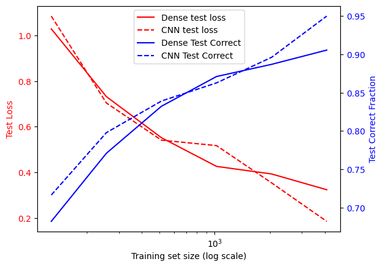

```python
fig, ax = plt.subplots()

ax.plot(n_trains, test_losses, "r-", label="Dense test loss")
ax.plot(n_trains, test_cnn_losses, "r--", label="CNN test loss")
ax.set_xscale("log")
ax.set_xlabel("Training set size (log scale)")
ax.set_ylabel("Test Loss", color="r")
ax.tick_params(axis="y", labelcolor="r")

ax2 = ax.twinx()
ax2.plot(n_trains, test_corrects, "b-", label="Dense Test Correct")
ax2.plot(n_trains, test_cnn_corrects, "b--", label="CNN Test Correct")
ax2.set_ylabel("Test Correct Fraction", color="b")
ax2.tick_params(axis="y", labelcolor="b")

lines1, labels1 = ax.get_legend_handles_labels()
lines2, labels2 = ax2.get_legend_handles_labels()
ax.legend(lines1 + lines2, labels1 + labels2, loc=9)

plt.show()
```

#### Task

Discuss below the differences of the `DenseNetwork` and `CNN` models and their respective advantages and disadvantages. Discuss the models you have trained in the broader context of dense and convolutional neural networks, including the state-of-the-art, using literature sources.

[3 mark]

The `DenseNetwork` interprets the image as a flat vector, learning patterns from data. In turn, it is more prone to idiosyncratic classifications for unseen data. The key advantage here is that it is fast to develop but requires longer training periods with more data to perform as robustly as a CNN. The `CNN` model preserves the spatial structure using 2D arrays, yielding higher accuracy however it takes longer to develop as it has varying architectural choices (i.e. kernel sizing, pooling, dense layers). This can take longer to train.

The CNN has been the dominant mode of image recognition in the field of Computer Vision, from biomedical image processing (https://doi.org/10.1016/j.neucom.2020.04.157) to facial recognition software (https://doi.org/10.1016/j.measen.2023.100800). Its applications are used beyond traditional image detection; time-series data can be converted into images (via Gramian Angular Fields), with CNNs used to predict future data points (https://doi.org/10.48550/arXiv.2504.00378). Whilst state-of-the-art (SOTA) models incorporate attention-based layers (https://doi.org/10.48550/arXiv.2010.11929), large-scale pretraining is required, leaving CNNs as an attractive substitute, with modern CNN performances remaining highly competitive (i.e. ConvNets: https://doi.org/10.48550/arXiv.2010.11929)

DenseNetworks still serve as the baseline for regressional and classification problems within data science applications. MLP-based vision models offer the performance of SOTA models with competitive inference and pretraining costs (https://doi.org/10.48550/arXiv.2010.11929)

# PX457 Assignment 6: Machine Learning for image recognition

### Dr Albert Bartók-Pártay, University of Warwick (2026)

#### marks: 15% of PX457 (2.25 CATs)

## Context

This assignment focusses on computer vision, and in particular, image recognition using neural networks. This family of techniques has applications in dozens of fields, but we are going to look at a few basic concepts which illustrate general practices in the field of Machine Learning.

Computer vision can assist with quantification of image analysis: in the current context it can essentially "view" large numbers of images and perform tasks that humans can do, but not necessarily in a consistent, automated manner, such as identifying the defects present in each one.

We will first familiarise ourselves with techinques by applying them to a well-known dataset, the `Hello World` of computer vision: the [MNIST handwritten digit dataset](https://en.wikipedia.org/wiki/MNIST_database). Due to resource limitations (mainly the lack of GPUs on Noteable) we will be using very small and limited models, only applying a fraction of the available data. However, the concepts used here can be easily scaled up in production environments.

## Instructions

Follow the notebook: read the description of the various concepts and run the code cells in sequence. At *Tasks*, you are expected to complete the code or write a short discussion, as [Markdown](https://www.markdownguide.org/) text - you needn't worry about formatting and feel free to write plain text.

Wherever you are expected to write code, you will see `raise NotImplementedError()`. This blocks the cell execution and serves as a reminder to complete a coding task. You should delete this line and replace it with your code.

Please do not duplicate cells, that includes copy-pasting entire cells. You may copy-paste the content of a cell, or make brand new cells. Please do not change the type of the cell. This notebook uses **code** and **markdown** cells - keep these as they are. Please note that autograding will run the entire notebook sequentially, therefore make sure you test your work in a similar fashion.

The entire notebook, when completed according to instructions, should take not more than 10 minutes to run. Please do not exceed this runtime. If your code takes significantly longer to run, it's due to either a mistake or not following the instructions closely.

Before you submit this assignment, make sure everything runs as expected. First, **restart the kernel** (in the menubar, select *Kernel*$\to$*Restart Kernel*) and then run all cells (in the menubar, select *Run*$\to$*Run All Cells*).

Make sure you fill in any place that says `YOUR CODE HERE` or `YOUR ANSWER HERE`, as well as your name below. Use the quotation marks `"` around your name, otherwise your notebook will not validate or run.

Remove all instances of `raise NotImplementedError()` which are placeholders, otherwise your code will not validate or run.

```python
# YOUR CODE HERE
YOUR_NAME = "Jabir Hussain"
```

## Environment Setup

The model we will build is based on PyTorch, and its extension TorchVision, so let us first check that our Python environment includes those.

To visualise our models, we will use the `torchview` package, which should be installed first.

```python
import torch
# if your environment does not have torch or torchvision, you can pip install it with this command (uncomment to use)
#!pip install torchvision==0.18.1
# but please avoid doing so if possible - the "Language and Machine Learning" environment has it preinstalled
import torchvision
print('Torch version: ',torch.__version__)
print('Torchvision version: ',torchvision.__version__)

!pip install --user torchview
"""
import sys, site, importlib.util

print("python:", sys.executable)
print("user site:", site.getusersitepackages())
print("ENABLE_USER_SITE:", site.ENABLE_USER_SITE)


print("find_spec(torchview):", importlib.util.find_spec("torchview"))

user_site = site.getusersitepackages()
if user_site not in sys.path:
    sys.path.insert(0, user_site)

print("find_spec(torchview) after path fix:", importlib.util.find_spec("torchview"))

# Now try importing
import torchview
from torchview import draw_graph
print("torchview imported from:", torchview.__file__)
"""
```

```
Torch version:  2.5.1
Torchvision version:  0.20.1
```

[output not shown]

```python
# a few imports

import matplotlib.pyplot as plt
import numpy as np

import torch
import torch.nn as nn
import torch.nn.functional as F
import torch.optim as optim
from torchvision import datasets, transforms
from torch.utils.data import Subset
from torch.optim.lr_scheduler import StepLR

from torchview import draw_graph
from tabulate import tabulate # to print simple tables
from tqdm import tqdm
```

The MNIST dataset is composed of greyscale image files of the digits together with their target labels. To make the image files useful for ML, a transform is defined below. This converts the image pixels into $28\times 28$ `torch` tensors.

```python
transform=transforms.Compose([
        transforms.ToTensor(),
        ])
```

```python
all_train = datasets.QMNIST('./data', what="train", download=True,
                       transform=transform)
all_test = datasets.QMNIST('./data', what="test10k", download=True,
                       transform=transform)
```

#### Inspect the type of data.

```python
print(f"Number of training data points: {len(all_train)}")
print(f"Number of test data points: {len(all_train)}")

image, label = all_train[0] # Each data point is a tuple: image and corresponding label
print(f"Shape of tensor representing an image: {image.shape}") # Note the shape of the tensor: 1 channel (intensity only), 28 x 28 pixels
print(f"Label: {label}") # The label is an integer between 0 and 9
```

```
Number of training data points: 60000
Number of test data points: 60000
Shape of tensor representing an image: torch.Size([1, 28, 28])
Label: 5
```

#### Inspect the first 16 digits. Do the labels look accurate?

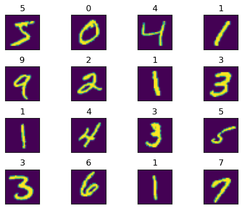

```python
fig, axes = plt.subplots(4,4,gridspec_kw={"hspace":0.5})
for ax,(image,label) in zip(axes.flatten(),all_train):
    ax.imshow(image[0]) # We only care about the one and only channel. Each image is 28 x 28 pixels.
    ax.set_xticks([])
    ax.set_yticks([])
    ax.set_title(label)
plt.show()
```

```python
n_train = 2048
train_indices = np.random.choice(len(all_train),n_train,replace=False)
train_set = Subset(all_train,train_indices)

test_set = all_test
```

```python
train_loader = torch.utils.data.DataLoader(train_set,batch_size = 64)
test_loader = torch.utils.data.DataLoader(test_set,batch_size = 1000)
```

#### The first neural network model

We first build a dense neural network, with a single hidden layer.

This model

1. flattens the $28\times 28$ pixel values into a 1D array, $\mathbf{x}_0$, of $28\times 28 = 784$ numbers;
2. $\mathbf{x}_0$ is transformed into a new vector $\mathbf{x}_1$ of a length of 15, using a parameter matrix $\mathbf{W}_1$ and bias vector $\mathbf{b}_1$: $\mathbf{x}_1 = \mathbf{W}_1 \mathbf{x}_0 + \mathbf{b}_1$
3. the elements of $\mathbf{x}_1$ are passed through the rectified linear unit (ReLU) function, obtaining $\mathbf{x}_1'$: $\mathbf{x}_1' = \mathrm{ReLU}(\mathbf{x}_1)$
4. $\mathbf{x}_1'$ is transformed into a new vector $\mathbf{x}_2$ of a length of 10, using a parameter matrix $\mathbf{W}_2$ and bias vector $\mathbf{b}_2$: $\mathbf{x}_2 = \mathbf{W}_2 \mathbf{x}_1' + \mathbf{b}_2$
5. the elements of $\mathbf{x}_2$ are passed through the $\log \mathrm{softmax}$ function, obtaining $\tilde{\mathbf{y}}$

$\tilde{\mathbf{y}}$ is the output of the model. We are fitting to 10 categories, therefore we define $\tilde{\mathbf{y}}$ as a 10-element vector. The $i$-th element of $\tilde{\mathbf{y}}$ corresponds to the log probability of digit $i$, given the input vector $\mathbf{x}_0$.

Below is a visual representation of the neural network. Not all the 784 input features are represented.

[figure not shown]

```python
class DenseNetwork(nn.Module):
    def __init__(self):
        super(DenseNetwork, self).__init__()
        self.fc1 = nn.Linear(784,15) # The first weight matrix and bias vector
        self.fc2 = nn.Linear(15,10) # The second weight matrix and bias vector

    def forward(self, x):
        x = torch.flatten(x, 1) # step 1
        x = self.fc1(x) # step 2
        x = F.relu(x) # step 3
        x = self.fc2(x) # step 4
        output = F.log_softmax(x, dim=1) # step 5
        return output
```

#### Activation functions

The rectified linear unit (ReLU) function is very popular and it is defined as $$\textrm{ReLU}(x)=\begin{cases} x & \textrm{if}\quad x>0\\ 0 & \textrm{otherwise} \end{cases}$$

The $\log \textrm{softmax}$ function operates on a vector input $\mathbf{x}$, resulting in $\mathbf{y}$, where $$y_i = \log \left( \frac{\exp(x_i)}{\sum_j \exp(x_j)} \right) $$

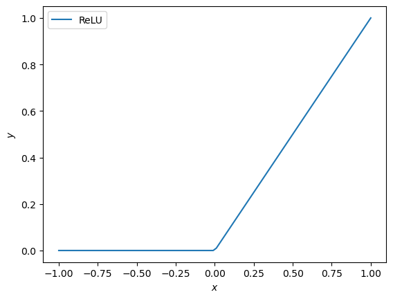

```python
# Visualising the ReLU function

x = torch.linspace(-1,1,100)
relu_x = F.relu(x)
plt.plot(x,relu_x,label="ReLU")
plt.xlabel(r"$x$")
plt.ylabel(r"$y$")
plt.legend()
plt.show()
```

```python
model = DenseNetwork() # Based on the model definition, we generate an instance of the model, with random weights.
```

#### Visualise the model

You will not be the first person finding the model definition somewhat confusing. We can use the `draw_graph()` method to visualise the computational graph - note that it needs to build it first, hence the requirement of `input_data`.

Parameters are stored as tensors. Those which are free to be optimised have the attribute `requires_grad` set to `True`.

```python
for param in model.parameters():
    print(type(param), param.requires_grad, param.size())
```

```
<class 'torch.nn.parameter.Parameter'> True torch.Size([15, 784])
<class 'torch.nn.parameter.Parameter'> True torch.Size([15])
<class 'torch.nn.parameter.Parameter'> True torch.Size([10, 15])
<class 'torch.nn.parameter.Parameter'> True torch.Size([10])
```

```python
image, label = all_train[0] # Each data point is a tuple: image and corresponding label

image = image[None,:,:,:] # We add an extra axis to the front

model_graph = draw_graph(model,input_data=image)
model_graph.visual_graph
```

[figure not shown]

```python
# This is also informative:
print(model)
```

```
DenseNetwork(
  (fc1): Linear(in_features=784, out_features=15, bias=True)
  (fc2): Linear(in_features=15, out_features=10, bias=True)
)
```

#### Task

Determine the number of adjustable (trainable) parameters in the `DenseNetwork` model.

[1 mark]

```python
n_trainable_parameters = 0

for p in model.parameters():
    if p.requires_grad:
        n_trainable_parameters += p.numel()
```

#### Initial model performance

Since the model was initiated with random parameters, we don't expect to do very well. Let's try with the first data point.

```python
image, label = all_train[0] # Each data point is a tuple: image and corresponding label
image = image[None,:,:,:]

print(model(image))
```

```
tensor([[-2.3050, -2.3909, -2.1992, -2.4667, -2.1613, -2.4126, -2.2751, -2.3368,
         -2.3982, -2.1381]], grad_fn=<LogSoftmaxBackward0>)
```

#### Initial model performance

You'll likely observe that each 10 categories have roughly equal predicted log probabilities, in accordance with a randomly initialised model.

#### Fitting the model

To fit the model we need to define a loss. We will use the **negative log likelihood** loss function, a common choice in classification tasks. $$\mathcal{L} = -\sum_{i\in \mathrm{batch}} \tilde{y}_{t_i}(\mathbf{x}_i)$$

where $t_i$ is the target label of the $i$-th data point in the batch, $\tilde{y}_{t_i}$ is the $t_i$-th element of the predicted $\tilde{\mathbf{y}}$ vector at data point $\mathbf{x}_i$. Remember that $\tilde{\mathbf{y}}(\mathbf{x}_i)$ is the output of the $\log \textrm{softmax}$ function. The optimiser will *minimise* this loss function, therefore *maximising* the predicted log likelihood of the correct label prediction.

In prediction mode, we simply choose the index of the largest predicted log likelihood - this is the category assigned by the model to the datapoint.

```python
def train(model, train_loader, optimizer, epoch, device = "cpu"):

    for batch_idx, (data, target) in enumerate(train_loader): # go through all batches within the training data set
        data, target = data.to(device), target.to(device) # extract image data and target
        optimizer.zero_grad() # reset gradients
        output = model(data) # determine the outputs of all data points within the batch with the current model
        loss = F.nll_loss(output, target) # calculate the loss corresponding to the data points within the batch
        loss.backward() # calculate the gradients using backpropagation, w.r.t. all parameters in the model
        optimizer.step() # advance the parameters using the gradients.
        if batch_idx % 16 == 0: # print progress
            print('Train Epoch: {} [{}/{} ({:.0f}%)]\tLoss: {:.6f}'.format(
                epoch, batch_idx * len(data), len(train_loader.dataset),
                100. * batch_idx / len(train_loader), loss.item()))

def test(model, test_loader, device = "cpu"):
    test_loss = 0
    correct = 0
    with torch.no_grad(): # no need for gradients
        for data, target in test_loader: # go through all batches within the testing data set
            data, target = data.to(device), target.to(device) # extract image data and target
            output = model(data) # determine the outputs of all data points within the batch with the current model
            test_loss += F.nll_loss(output, target, reduction='sum').item()  # sum up batch loss
            pred = output.argmax(dim=1, keepdim=True)  # get the index of the max log-probability
            correct += pred.eq(target.view_as(pred)).sum().item() # calculate how many predictions are correct

    test_loss /= len(test_loader.dataset) # average the loss

    print('\nTest set: Average loss: {:.4f}, Accuracy: {}/{} ({:.0f}%)\n'.format(
        test_loss, correct, len(test_loader.dataset),
        100. * correct / len(test_loader.dataset)))

    return test_loss, correct / len(test_loader.dataset)
```

```python
# We apply a simple optimiser
optimizer = optim.Adadelta(model.parameters(), lr=1)
```

```python
# Training the network
num_epochs = 16
for epoch in range(1, 1+num_epochs):
        train(model, train_loader, optimizer, epoch)
        test(model, test_loader)
```

```
Train Epoch: 1 [0/2048 (0%)]	Loss: 2.326623
Train Epoch: 1 [1024/2048 (50%)]	Loss: 1.740995

Test set: Average loss: 1.0922, Accuracy: 7022/10000 (70%)

Train Epoch: 2 [0/2048 (0%)]	Loss: 1.225615
Train Epoch: 2 [1024/2048 (50%)]	Loss: 0.828513

Test set: Average loss: 0.6290, Accuracy: 8362/10000 (84%)

Train Epoch: 3 [0/2048 (0%)]	Loss: 0.713618
Train Epoch: 3 [1024/2048 (50%)]	Loss: 0.587480

Test set: Average loss: 0.4962, Accuracy: 8662/10000 (87%)

Train Epoch: 4 [0/2048 (0%)]	Loss: 0.519756
Train Epoch: 4 [1024/2048 (50%)]	Loss: 0.480283

Test set: Average loss: 0.4421, Accuracy: 8768/10000 (88%)

Train Epoch: 5 [0/2048 (0%)]	Loss: 0.430336
Train Epoch: 5 [1024/2048 (50%)]	Loss: 0.411987

Test set: Average loss: 0.4145, Accuracy: 8825/10000 (88%)

Train Epoch: 6 [0/2048 (0%)]	Loss: 0.376924
Train Epoch: 6 [1024/2048 (50%)]	Loss: 0.361840

Test set: Average loss: 0.3973, Accuracy: 8839/10000 (88%)

Train Epoch: 7 [0/2048 (0%)]	Loss: 0.339756
Train Epoch: 7 [1024/2048 (50%)]	Loss: 0.323679

Test set: Average loss: 0.3873, Accuracy: 8857/10000 (89%)

Train Epoch: 8 [0/2048 (0%)]	Loss: 0.310633
Train Epoch: 8 [1024/2048 (50%)]	Loss: 0.293594

Test set: Average loss: 0.3800, Accuracy: 8882/10000 (89%)

```

[output cut: 24 more lines]

```

Train Epoch: 14 [0/2048 (0%)]	Loss: 0.201505
Train Epoch: 14 [1024/2048 (50%)]	Loss: 0.195816

Test set: Average loss: 0.3689, Accuracy: 8949/10000 (89%)

Train Epoch: 15 [0/2048 (0%)]	Loss: 0.189252
Train Epoch: 15 [1024/2048 (50%)]	Loss: 0.186426

Test set: Average loss: 0.3700, Accuracy: 8944/10000 (89%)

Train Epoch: 16 [0/2048 (0%)]	Loss: 0.179409
Train Epoch: 16 [1024/2048 (50%)]	Loss: 0.176791

Test set: Average loss: 0.3708, Accuracy: 8943/10000 (89%)
```

#### Evaluation of the model and further insights

In the following, we evaluate the model on all test images. We then determine the [confusion matrix](https://en.wikipedia.org/wiki/Confusion_matrix#Confusion_matrices_with_more_than_two_categories): for every digit between 0-9, we count how many were predicted in each category. A perfect model would result in an exactly diagonal matrix. Below we print the table and also visualise it as a heatmap.

```python
all_test_predict = np.array([])
all_test_actual = np.array([])
for data, target in test_loader: # go through all batches within the testing data set
    data, target = data.to("cpu"), target.to("cpu") # extract image data and target
    output = model(data) # determine the outputs of all data points within the batch with the current model

    ind = output.argmax(dim=1, keepdim=False)


    all_test_predict = np.concatenate((all_test_predict,ind))
    all_test_actual = np.concatenate((all_test_actual,target))
```

```python
confusion_matrix = np.array([[np.count_nonzero(all_test_predict[all_test_actual==i]==j) for j in range(10)] for i in range(10) ])
```

```
┌────┬─────┬──────┬─────┬─────┬─────┬─────┬─────┬─────┬─────┬─────┐
│    │   0 │    1 │   2 │   3 │   4 │   5 │   6 │   7 │   8 │   9 │
├────┼─────┼──────┼─────┼─────┼─────┼─────┼─────┼─────┼─────┼─────┤
│  0 │ 934 │    0 │   5 │   2 │   0 │  27 │   6 │   2 │   3 │   1 │
│  1 │   0 │ 1105 │   4 │   7 │   1 │   0 │   3 │   1 │  14 │   0 │
│  2 │  11 │    5 │ 878 │  28 │  20 │   9 │   9 │  21 │  50 │   1 │
│  3 │   3 │    2 │  25 │ 892 │   1 │  46 │   0 │  11 │  23 │   7 │
│  4 │   2 │    3 │   3 │   3 │ 926 │   1 │  12 │   2 │  10 │  20 │
│  5 │   6 │    2 │   6 │  36 │  26 │ 761 │   9 │   6 │  32 │   8 │
│  6 │  16 │    3 │  14 │   1 │  12 │  30 │ 873 │   2 │   6 │   1 │
│  7 │   0 │    8 │  36 │   6 │  10 │   1 │   0 │ 933 │   4 │  30 │
│  8 │   7 │    7 │   7 │  25 │  19 │  58 │  10 │  15 │ 822 │   4 │
│  9 │   9 │    7 │  10 │  16 │ 114 │  12 │   0 │  11 │  11 │ 819 │
└────┴─────┴──────┴─────┴─────┴─────┴─────┴─────┴─────┴─────┴─────┘
```

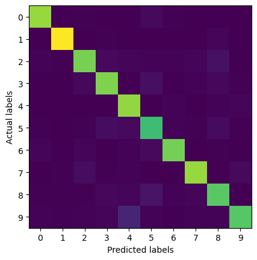

```python
print(tabulate(confusion_matrix, showindex=True, headers=range(10), tablefmt="simple_outline"))
fig, ax = plt.subplots(1,1)
ax.imshow(confusion_matrix)
ax.set_xticks(range(10))
ax.set_yticks(range(10))
ax.set_xlabel("Predicted labels")
ax.set_ylabel("Actual labels")
plt.show()
```

### Choosing between procedures and models: **validation**

So far, we have used two data sets: training and testing.

- The **training** set was used to calculate the gradients w.r.t. the model parameters and to optimise the model.
- The **test**, independent of the training set, was used to evaluate the performance of the model on **unseen** data. The main purpose of the **test** set is to assess the real-world performance of the model, therefore it should not be contaminated with the **training** set.

It is common to use a third data set, called the **validation** set. There are no set rules, but typically the validation set is a subset of the training set, and it is usually smaller than the training or the test set. The purpose of the validation set is to avoid overfitting: that is, to monitor the performance of the models during optimisation, or to compare models obtained with different hyperparameters (e.g. learning rates, network architecture, etc.)

Here we will use the validation set to calculate the **validation loss** as well as the percentage of correct assignments on the validation set.

```python
# Update the train() function to calculate the validation loss in every epoch.

def train(model, train_loader, validation_loader, optimizer, epoch, device = "cpu"):

    for batch_idx, (data, target) in enumerate(train_loader): # go through all batches within the training data set
        data, target = data.to(device), target.to(device) # extract image data and target
        optimizer.zero_grad() # reset gradients
        output = model(data) # determine the outputs of all data points within the batch with the current model
        loss = F.nll_loss(output, target) # calculate the loss corresponding to the data points within the batch
        loss.backward() # calculate the gradients using backpropagation, w.r.t. all parameters in the model
        optimizer.step() # advance the parameters using the gradients.

    validation_loss = 0
    validation_correct = 0
    with torch.no_grad(): # no need for gradients
        for data, target in validation_loader:
            data, target = data.to(device), target.to(device) # extract image data and target
            output = model(data) # determine the outputs of all data points within the batch with the current model
            validation_loss += F.nll_loss(output, target, reduction='sum').item()  # sum up batch loss
            pred = output.argmax(dim=1, keepdim=True)  # get the index of the max log-probability
            validation_correct += pred.eq(target.view_as(pred)).sum().item() # calculate how many predictions are correct
    return validation_loss, validation_correct / len(validation_loader.dataset)
```

We take the last 1024 of the original training data points and reserve them as a validation set.

```python
n_validation = 1024
validation_indices = range(len(all_train)-n_validation,len(all_train)) # Last n_validation points
validation_set = Subset(all_train,validation_indices)

validation_loader = torch.utils.data.DataLoader(validation_set,batch_size=64)
```

In the following, we will always choose the training set such that the validation points are excluded.

```python
n_train = 1024

train_indices = np.random.choice(len(all_train)-n_validation,n_train,replace=False) # Random indices from all training data points except the last n_validation
train_set = Subset(all_train,train_indices)
train_loader = torch.utils.data.DataLoader(train_set,batch_size = 64)
```

#### Monitoring the progress of training

Run the following code to capture the validation loss and the fraction of correct assignments for every epoch, using the updated `train()` function.

```python
num_epochs = 128

model = DenseNetwork() # Based on the model definition, we generate an instance of the model, with random weights.
optimizer = optim.Adadelta(model.parameters(), lr=1)

loss = []
correct = []
for epoch in tqdm(range(1, 1+num_epochs)):
    validation_loss, validation_correct = train(model, train_loader, validation_loader, optimizer, epoch)
    loss.append(validation_loss)
    correct.append(validation_correct)

loss = np.array(loss)
correct = np.array(correct)
```

We plot the validation loss and the fraction of correct assignments as a function of epochs.

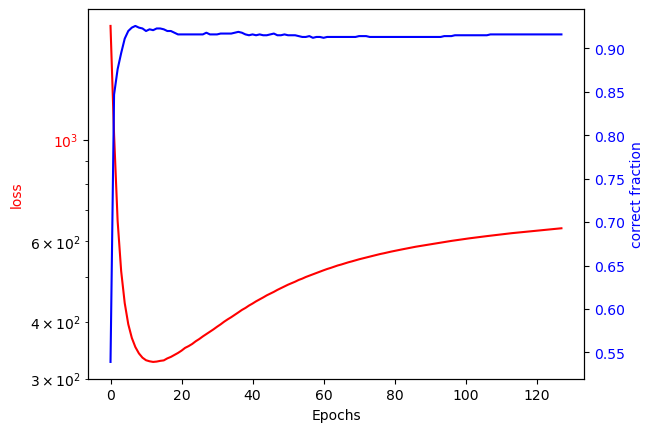

```python
fig, ax1 = plt.subplots()

ax1.semilogy(loss,"r")
ax2 = ax1.twinx()
ax2.plot(correct,"b")

ax1.set_xlabel("Epochs")
ax1.set_ylabel("loss",color="r")
ax1.tick_params(axis='y', labelcolor="r")

ax2.set_ylabel("correct fraction",color="b")
ax2.tick_params(axis='y', labelcolor="b")
#plt.plot(loss)
#plt.plot(correct)
plt.show()
```

#### Task

Discuss the obtained figure. Explain how our optimisation procedure gives rise to the observed behaviour.

[1 mark]

For the early epochs, the negative log-likelihood is high with low accuracy. This is because the network starts with almost uniform class probabilities. As the number of epochs goes, the model has learned as much as it can within the confinements of the dataset, so the correct fraction plateaus. On the other hand, the loss increases with the number of epochs since the optimiser continues to update the model weights. The negative log-likelihood depends on the probability of the true label. The set of misclassified validation points becomes fixed, thus the confidence in their incorrectness makes the log-probability for true values smaller and thus negative log-likelihood increases.

#### Hold out method

A common practice is to take the best performing model during the optimisation, and use that as the definitive model. You can take a "snapshot" of a model by using the `deepcopy()` function or save the model to the disk.

```python
from copy import deepcopy
```

```python
save_model = deepcopy(model) # save_model is now an exact and independent replica of model
```

#### Task

In the following cell, implement the **hold out** method, using the validation loss. At the end of the training:

- `best_loss` should contain the lowest value of the validation loss
- `best_correct` the corresponding value of the fraction of correctly assigned validation data points
- `best_epoch` the corresponding index of epoch
- `best_model` the corresponding best performing model.

[1.5 mark]

```python
model = DenseNetwork() # Based on the model definition, we generate an instance of the model, with random weights.
optimizer = optim.Adadelta(model.parameters(), lr=1)

num_epochs = 128

loss = []
correct = []

best_loss = float("inf")
best_correct = 0
best_epoch = 0
best_model = deepcopy(model)

for epoch in tqdm(range(1, 1+num_epochs)):
    validation_loss, validation_correct = train(model, train_loader, validation_loader, optimizer, epoch)
    loss.append(validation_loss)
    correct.append(validation_correct)
    if validation_loss < best_loss:
        best_loss = validation_loss       # Update new best loss record
        best_correct = validation_correct # Update corresponding accuracy
        best_epoch = epoch                # Record epoch this happened in
        best_model = deepcopy(model)

loss = np.array(loss)
correct = np.array(correct)

print(best_loss)
print(best_correct)
```

```
323.6614785194397
0.9228515625
```

#### Task

Now plot the progress of the optimisation, indicating with markers where the best performing model was obtained.

[0.5 mark]

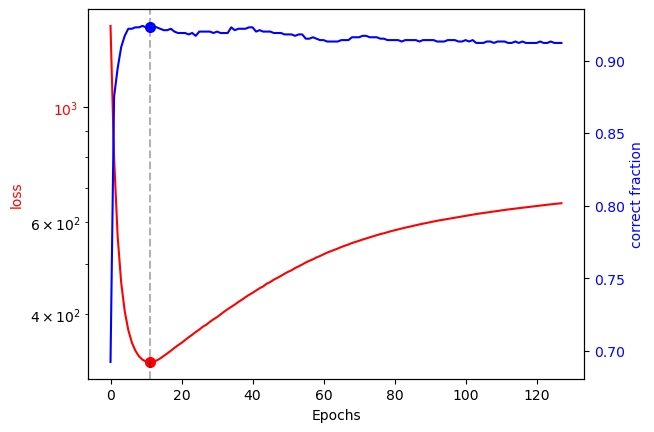

```
Test set: Average loss: 0.4268, Accuracy: 8775/10000 (88%)

(0.4267741653442383, 0.8775)
```

```python
fig, ax1 = plt.subplots()

ax1.semilogy(loss,"r")

ax2 = ax1.twinx()
ax2.plot(correct,"b")

best = int(np.argmin(loss))
ax1.semilogy(best, loss[best], "ro", markersize=7)
ax2.plot(best, correct[best], "bo", markersize=7)
ax1.axvline(best, color="k", linestyle="--", alpha=0.3)

ax1.set_xlabel("Epochs")
ax1.set_ylabel("loss",color="r")
ax1.tick_params(axis='y', labelcolor="r")

ax2.set_ylabel("correct fraction",color="b")
ax2.tick_params(axis='y', labelcolor="b")
#plt.plot(loss)
#plt.plot(correct)
plt.show()

# Model perfomance on best model
print(test(best_model, test_loader))
```